# Tuleviku prognoosimine

## Sissejuhatus aegridade analüüsi

Tavastatistika aegridade puhul ei aita, sest aegridade puhul eiratakse ühte põhilist eeldust statistikas - vaatluste sõtlumatus. Selle tõttu võib tavastatistika mudel väga imelikke tulemusi anda:

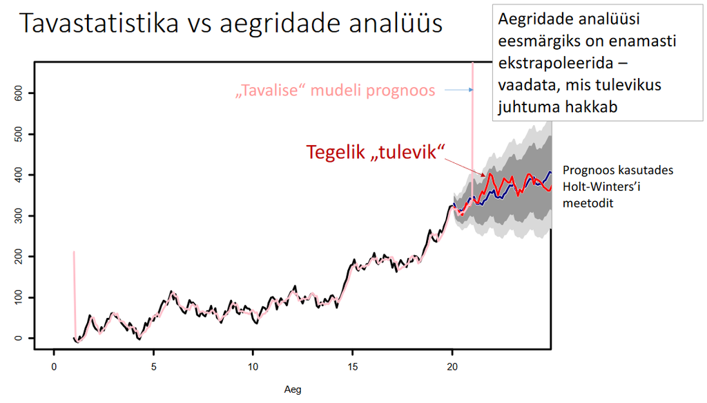

## Andmete ettevalmistus

Proovime leida prognoosi Tallinki reisijate arvu jaoks. Loeme sisse näiteandmed:

```r
# Allikas: https://www.tallink.com/reports#tabs-content-6
load(url("https://github.com/Rkursus/andmeanalyytik/raw/master/data/reisijaid.RData"))
head(Tallink)
```

```
##       kuupaev reisijaid
## 71 2012-05-01    736464
## 70 2012-06-01    894282
## 69 2012-07-01   1165349
## 68 2012-08-01    929055
## 67 2012-09-01    675743
## 66 2012-10-01    751993
```

```r
attach(Tallink)
```

ja teisendame andmed aegreaks:

```r
y = ts(reisijaid, start=c(2012,5), frequency=12)
y
```

```
##          Jan     Feb     Mar     Apr     May     Jun     Jul     Aug     Sep
## 2012                                  736464  894282 1165349  929055  675743
## 2013  556813  632376  706154  650462  792574  909451 1123456  930346  664976
## 2014  560587  643788  701180  709931  756101  897478 1092180  876013  593064
## 2015  538929  610785  643700  714895  758509  882635 1132786  936247  632379
## 2016  556750  632653  763667  704642  758509  909082 1188226  961851  705035
## 2017  561493  654048  724243  807616  803252  976165 1208156  980234  724369
## 2018  592380  622283  715786
##          Oct     Nov     Dec
## 2012  751993  673000  708170
## 2013  745331  673120  729753
## 2014  721733  647222  682455
## 2015  793219  620013  712129
## 2016  804639  654051  767630
## 2017  808383  692506  815255
## 2018
```

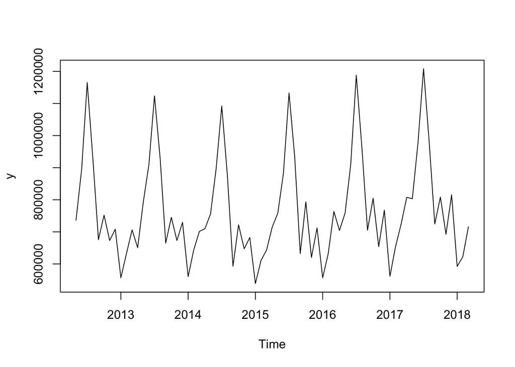

```r
plot(y)
```

## Aegrea analüüsimine

Järgnevalt hindame Holt-Winters’i mudeli, selle meetodi abil saame hinnata:

- Autoregressiivsust (*alpha*) - kuidas mõjutab eelmine kuu käesolevat.
- Trendi (*beta*) - kas ajas reisijate arv suureneb või väheneb stabiilselt?
- sesoonsust (*gamma*) - kas eelmise aasta muster kordub aastast aastasse? Nt suvel on rohkem reisijaid, talvel vähem aga detsembris on jälle natuke suurem reisijate liikumine jõulude tõttu.
- Iga üksiku kuu sesoonset mõju võrreldes keskmisega (*s1-s12*).

```r
m1 = HoltWinters(y, seasonal="mult")
m1
```

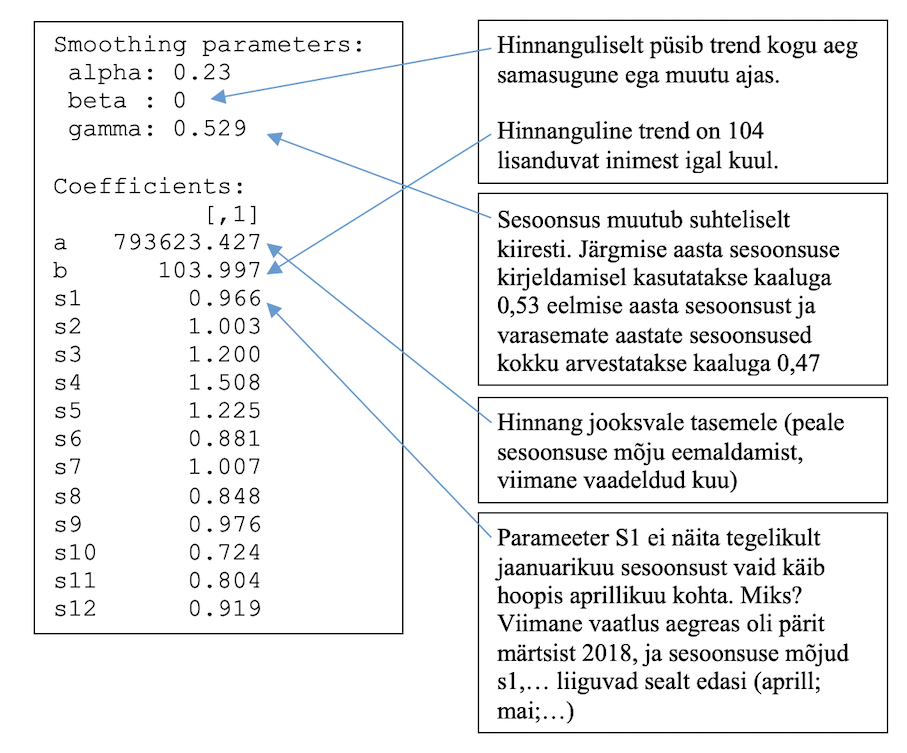

Järgnev joonis annab aimu kuidas erinevad aegrea komponendid on ajas käitunud, seal näed:

- *data* - algsed andmed ilma komponentideks lahku löömata.
- *seasonal* - sesoonsuse komponent, kuivõrd stabiilne on resisijate arvu muster aastast-aastasse.
- *trend* - kuidas on trend ajapikku muutunud.
- *remainder* - jääk, üldiselt kui “tulbad” jagunevad ühtlaselt, siis on komponentideks lahku löömine hästi õnnestunud.

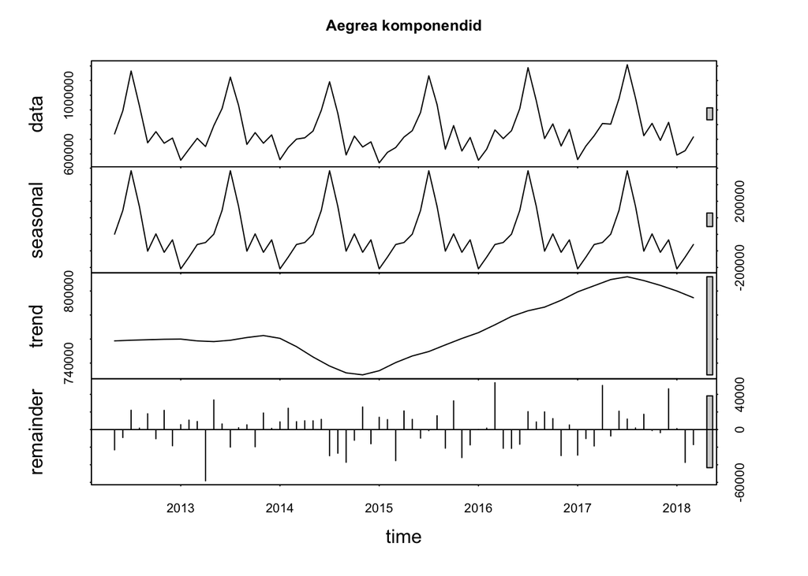

```r
plot(stl(y, "per"), main = "Aegrea komponendid")
```

Jooniste paremas servas olevad hallid kastid näitavad vastava komponendi skaalat, õigemin kui palju on pilti “suurendatud”. Kõige ülemine paneb paika skaala võrdlusbaasi. Ülal oleval joonisel on seega sesoonne komponent samas skaalas kui algandmed. Trendi komponendi pilti on aga tugevalt suurendatud, oleks skaala sama mis algandmetel, siis näeksime ilmselt vaid sirget joont.

## Prognoosimine

Kontrollime mudeli prognoosivõimet – kui hästi ta on *varem* suutnud tulevikku näha?

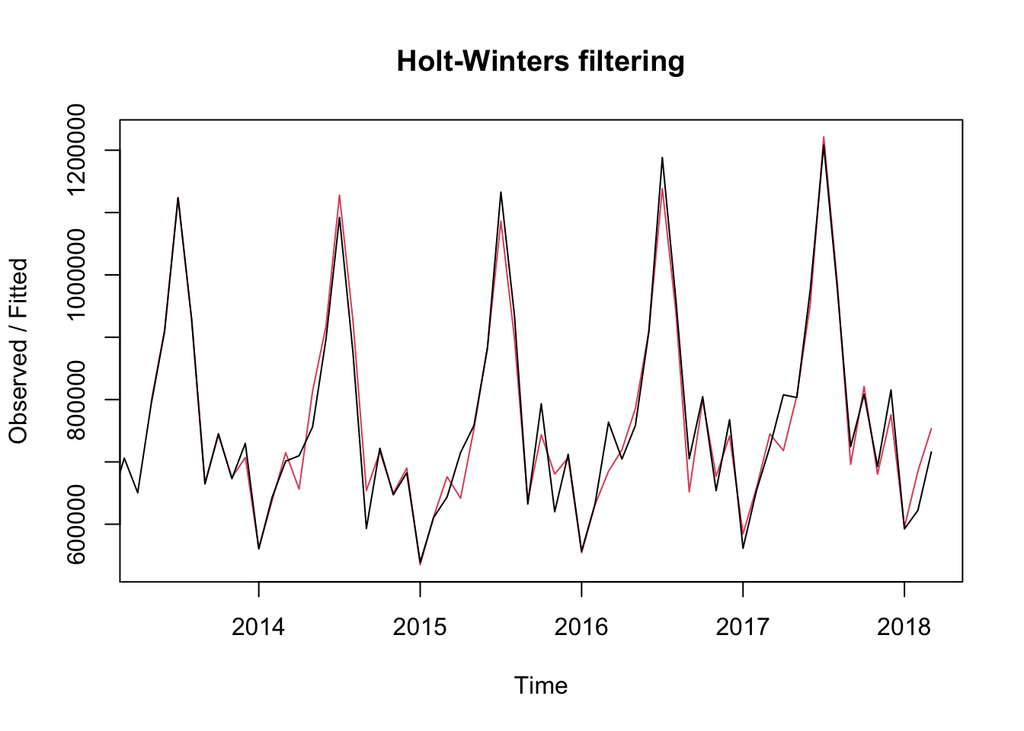

```r
plot(m1)
```

Prognoosime nüüd tulevikku aga esmalt veendu, et sul oleks `forecast` pakett paigaldatud ja töömällu loetud:

```r
install.packages('forecast')
library(forecast)
```

Prognoosime leitud mudeli abil kaks aastat (24 kuud) tulevikku

```r
prog = forecast(m1, h=24)
prog
```

```
##          Point Forecast   Lo 80   Hi 80   Lo 95   Hi 95
## Apr 2018         766949  740079  793819  725855  808043
## May 2018         796291  767597  824986  752406  840176
## Jun 2018         953021  921368  984674  904612 1001430
## Jul 2018        1197265 1161043 1233488 1141868 1252663
## Aug 2018         972762  938505 1007018  920371 1025152
## Sep 2018         699820  668129  731511  651353  748287
## Oct 2018         799579  764748  834410  746310  852849
## Nov 2018         673943  640214  707673  622358  725528
## Dec 2018         775355  737984  812725  718202  832508
## Jan 2019         575137  541303  608972  523391  626884
## Feb 2019         638712  601843  675581  582326  695098
## Mar 2019         730523  699595  761451  683222  777824
## Apr 2019         768155  719092  817219  693119  843191
## May 2019         797543  746643  848443  719699  875387
## Jun 2019         954519  897409 1011629  867177 1041861
## Jul 2019        1199147 1131956 1266338 1096388 1301907
## Aug 2019         974290  915125 1033456  883804 1064776
## Sep 2019         700920  650806  751033  624277  777562
## Oct 2019         800836  746168  855503  717229  884442
## Nov 2019         675002  624203  725801  597312  752692
## Dec 2019         776573  720870  832276  691382  861763
## Jan 2020         576041  527400  624681  501651  650430
## Feb 2020         639715  587575  691855  559973  719457
## Mar 2020         731670  687931  775409  664777  798563
```

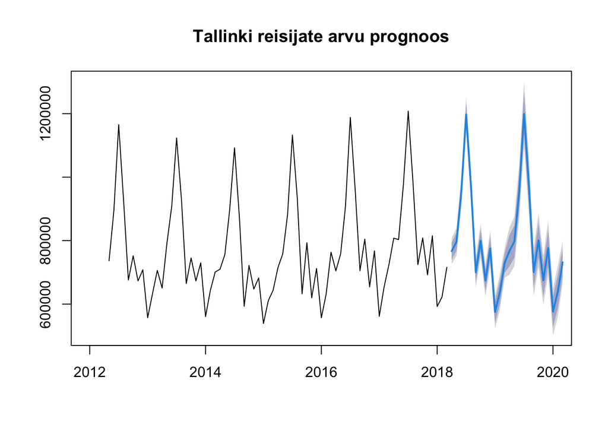

```r
plot(prog, xlim=c(2012, 2020), main="Tallinki reisijate arvu prognoos")
```

### Ülesanne nuputamiseks

*Millised järeldused saad teha vastavalt ülevel saadud joonisele? Kuivõrd täpne on prognoos? Millele see võib vihjata? Kuidas saab antud prognoosi kasutada ettevõtte igapäevases tegevuses?*

## Prognoosi võrdlus tegelikkusega

Lisame graafikule prognoositud perioodi tegelikud reisijate arvud:

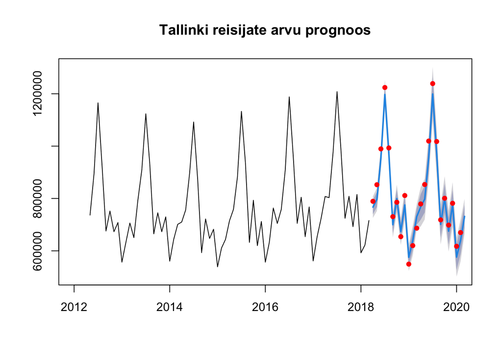

```r
plot(prog, xlim=c(2012, 2020), main="Tallinki reisijate arvu prognoos")
tegelik=c(789272, 852609, 989445, 1223901, 993078, 730631, 785583,
            654240, 811261, 549278, 620006, 686488, 779113,853309,1019421,
            1238871,1017565,718354,800828,698293,781684,617374,669849)
teg=ts(tegelik, start=c(2018, 4), frequency=12)
points(teg, col="red", cex=1.2, pch=20)
```

Veebruar-märts 2020 tabas Euroopat esimene COVID-19 laine ja paratamatult ei pea aegridade analüüs maailmat raputavate sündmuste puhul enam paika.

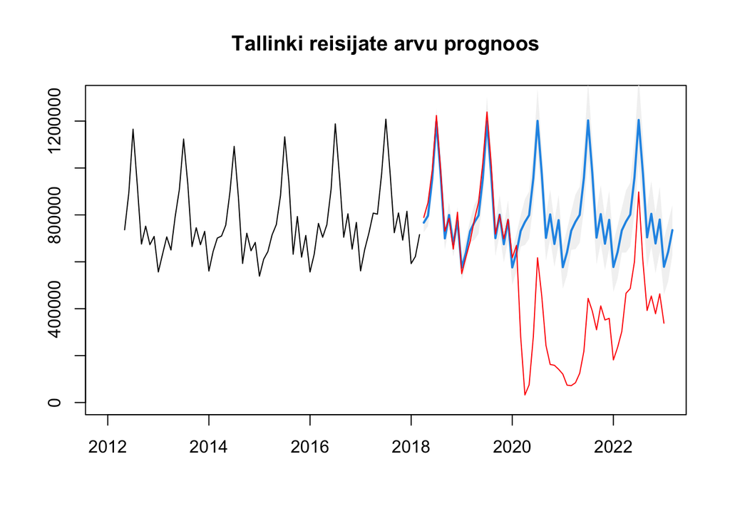

```r
prog = forecast(m1, h=60, level=0.95)
plot(prog, xlim=c(2012, 2023), ylim = c(0,1.3)*10^6,
     main="Tallinki reisijate arvu prognoos",
    shadecols=c("gray95", "gray85", "gray80", "gray75") )
tegelik=c(789272, 852609, 989445, 1223901, 993078, 730631, 785583,
            654240, 811261, 549278, 620006, 686488, 779113, 853309, 1019421,
            1238871, 1017565, 718354, 800828, 698293, 781684, 617374, 669849,
            279507, 32181, 75511, 280520, 617206, 453880, 243215, 162311, 158777,
            141771, 121116, 74129, 71979, 84347, 124470, 218950, 444112,389715,
        310265, 412046, 351857, 358989, 181687, 235214, 303360, 465945,
            485741, 600488, 897828, 603284, 392491, 454207, 378540, 463300, 338194)
teg=ts(tegelik, start=c(2018, 4), frequency=12)
lines(teg, col = "red", cex = 3)
```

### Ülesanne nuputamiseks

*Hinda Tallinki reisijate prognoosimudel uuesti kui `reisijaid` andmetele on juurde pandud hiljem lisatud 2018-2022. aasta andmed (`tegelik`). Prognoosi järgmise 12 kuu reisijate arvud. Milliseid otsuseid teeksid kui näeksid sellist prognoosi? Kas ostaksid Tallinki aktsiaid?*

```r
# "Keevita" algsed andmed ja hiljem lisatud tegelikud andmed. Muuda aegreaks:
y2 = ts(append(reisijaid, tegelik), start=c(2012,5), frequency=12)

# Joonista uus aegrida, lahuta komponentideks ja hinda komponente (trend, sesoonsus, juhuslik komponent)
... sinu kood ...

# Hinda Holt-Winters mudel
... sinu kood ...

# Prognoosi järgmised 12 kuud
... sinu kood ...
```

# ARIMA mudelid

On veel mudeleid, mille abil on võimalik aegrea struktuuri esitada ja ilmselt kuuled neist kui aegridadega kokku puutud, näiteks ARIMA mudelid. ARIMA ehk *AutoRegressive Integrated Moving Average* proovib samamoodi aegrea komponentideks lahti lõhkuda autoregressiivse strutuuri abil.

R-is on kindel abimees funktsioon `auto.arima()`

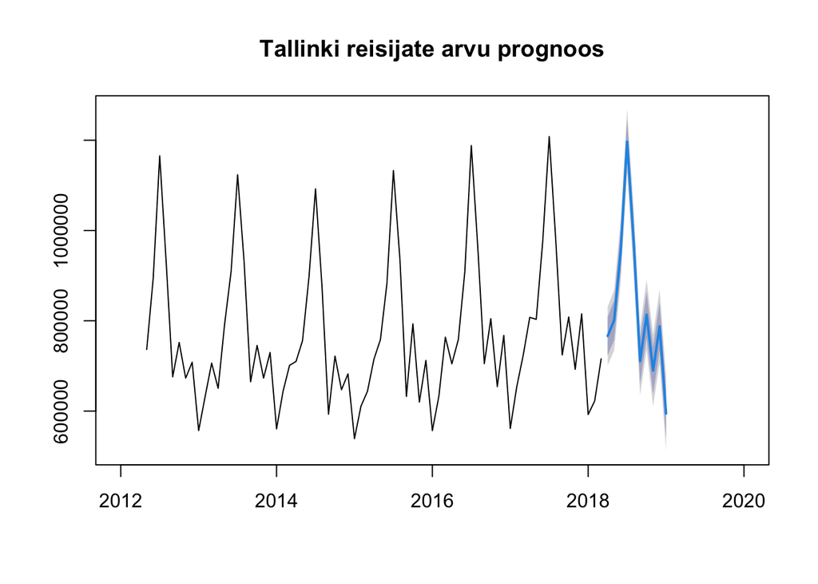

```r
y = ts(reisijaid, start=c(2012,5), frequency=12)
m2 = auto.arima(y)
prog2 = forecast(m2, h=10)
plot(prog2, xlim=c(2012, 2020), main="Tallinki reisijate arvu prognoos")
```

Võrdle tulemusi Holt-Winters mudeliga.